# Comportamiento del consumo de oxígeno y disponibilidad de camas en los hospitales del Perú entre los meses de marzo y septiembre del 2021

### Modelo 4: Modelo normal

Se realiza una distribución normal de la Variable Camas Ocupadas asumiendo un intervalo de confianza del 95%, para ver qué tanto se parece la agrupación de los datos a una distribución normal cuando se tiene una gran cantidad. La línea roja vendrá a ser la Gráfica Normal ajustada a nuestros datos, se considera el 95% porque se considerará que 95 de 100 datos obtenidos son verdaderos.

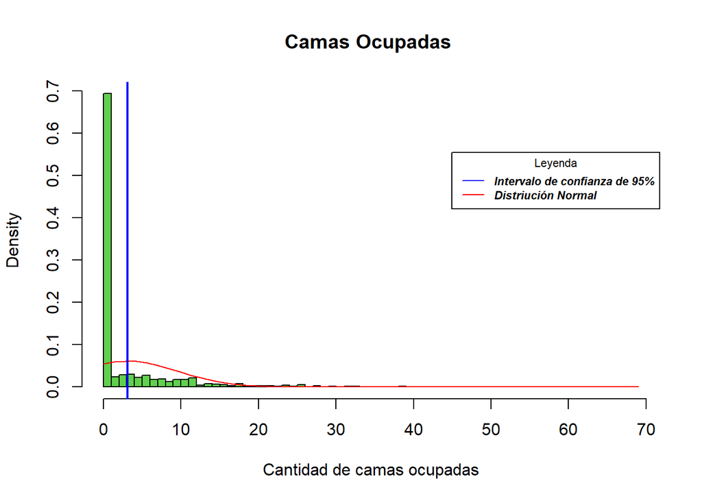

Las camas ocupadas según la gráfica mostrada está entre 0 y 20 aproximadamente, por lo que podemos ver que la gran mayoría de IPRESS en el Perú no pasa de 20 camas disponibles.

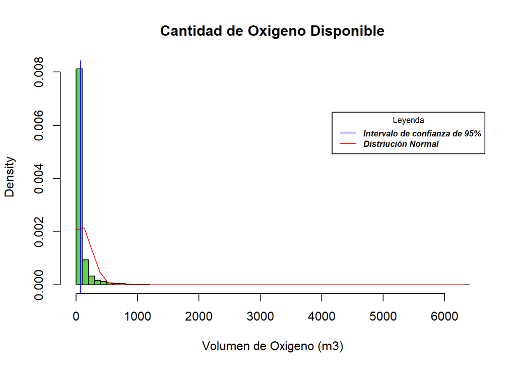

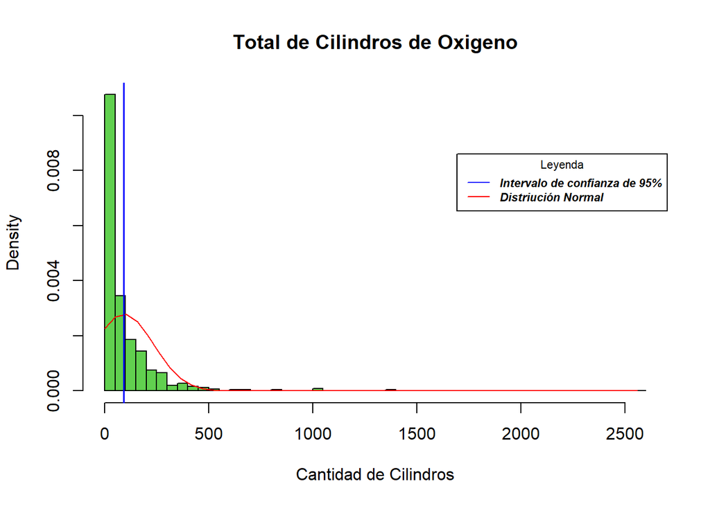

## Conclusiones

- La recoleccion de datos no fue la más óptima debido a que hubo gran cantidad de observaciones que estaban repetidas.
- A lo largo de todas las variables, se pudo reafirmar la diferencia de calidad entre cada uno de los niveles (1, 2 y 3)

- En Lima, a pesar de contar con más IPRESS que todas la regiones, las probabilidades de encontrar a un IPRESS apto para atender a un paciente COVID, que sea de carácter público y de nivel medio (NIVEL 2), es muy bajo

**BIBLIOGRAFÍA**

Ministerio de Salud (MINSA). Información por día de Disponibilidad y Consumo de Oxígeno Medicinal a nivel nacional. Recuperado de: https://www.datosabiertos.gob.pe/dataset/informaci%C3%B3n-por-d%C3%ADa-de-disponibilidad-y-consumo-de-ox%C3%ADgeno-medicinal-nivel-nacional-v2-desde

Ministerio de Salud (MINSA). Disponibilidad de camas para atenciones Covid19. Resuperado de: https://www.datosabiertos.gob.pe/dataset/disponibilidad-de-camas-para-atenciones-covid19

Ministerio de Salud (MINSA). Qué es una IPRESS. Recuperado de: https://www.gob.pe/institucion/minsa/noticias/14866-conoce-mas-sobre-susalud-y-como-protege-los-derechos-en-salud-de-los-peruanos

ESAN, C. (20 de Marzo de 2018). ¿Cómo funciona la categorización en establecimientos de salud? Obtenido de Conexión ESAN: https://www.esan.edu.pe/conexion-esan/como-funciona-la-categorizacion-en-establecimientos-de-salud